# Machine Learning 2020/2021: Assignment 1

## Students: Emanuel Tomé, Klismam Pereira, Luís Reis and Vânia Guimarães

Master's in Data Science and Master's in Bioinformatics and Computational Biology  
Department of Computer Sciences, Faculty of Sciences, University of Porto  
7th April 2021

## Introduction

Given a real-life phenomenon, Machine Learning algorithms attempt to explain the mechanisms of the process by searching for an approximation of the real underlying function that governs it. Moreover, it is common practice to choose the best possible model among several candidates through a criteria called **loss function**, which is useful because it penalizes wrong predictions and provides a way of calculating the **expected prediction error**, i.e. the best model minimizes the loss function and the expected prediction error.

In the context of classification, it can be shown that under certain conditions the approximated function that minimizes the expected prediction error is the **Bayes Classifier** (BC), shown below.

$$BC(x) = max_{(g\in G)}P(g|X = x)$$

$G$ is the set of classes, and $g$ is each individual class. Given an observation $x$, BC classifies it as the most probable class $g$. With regards to the Bayesian Decision Theory, the function also defines an optimal decision boundary known as **Bayes Decision Boundary** (BDB). It is clear, however, that obtaining the BDB requires previous knowledge on the conditional probabilities that govern the process, which is not the case for many real-life phenomenon.

Nonetheless, we can visualize the Bayes decision boundary in artificially generated datasets with predefined distributions of features, and compare it to the decision boundary generated by common methods applied in the field of Machine Learning, such as K Nearest Neighbors (KNN), Logistic Regression, Decision Trees, and so on. After all, these methods aim to approximate a function to the Bayes Classifier, thus ideally their decision boundaries should also resemble the Bayes Decision Boundary to some extent.

The main difference lies in how these methods attempt the approximation, some estimate globally while others locally, which influences the inherent bias-variance trade-off. For instance, in Logistic Regression it is assumed that the decision boundary is linear, i.e. the underlying function has a specific shape, therefore constraining the complexity of possible approximations, thus the reasoning is global. KNN's philosophy can be thought as local, as it assumes points near the observation are more similar to it, thus it uses the vote of the majority of points to classify the new case, allowing for more arbitrary decision boundaries that often can incurr in what is known as overfitting. Actually, Decision Trees often present this kind of problem, as in the extreme scenario the algorithm extends branches using hill climbing search procedure until each case is its own leave.

Still, there are hyperparameters used to control the expressiveness of models which try to reduce overfit. In Logistic Regression, one can use the regularization hyper parameter; in KNN, one can adjust the number of neighbors used to vote the class; and in Decision Trees, one might reduce the maximum size of the branches, increase the minimum number of cases in each leave, or perform pruning through a cost complexity hyper parameter.

The objective of this work is to perform experiments using the aforementioned Machine Learning methods in the context of classification tasks, visualize produced decision boundaries and compare them to the Bayes Decision Boundary when possible, and briefly discuss on their behavior regarding the bias-variance trade-off. The datasets used are:

- [Pima Indians Diabetes](https://www.kaggle.com/uciml/pima-indians-diabetes-database)
- [Yeast UCI dataset](https://archive.ics.uci.edu/ml/datasets/Yeast)

This work is divided in two parts:

- The answer to the question "how can we find an approximate decision boundary?" is explored using the Pima Dataset, which has 8 numerical variables and 2 classes.
- The answer to the question "model selection" is explored using the Yeast dataset, which has 8 numerical variables and 10 highly imbalanced classes.

#### Import of packages and data

```python
# Local Imports
from utils.classifier_utils import plot_classifier_boundary, knn_classifier_score
from utils.cv_evaluate_utils import split_finder, check_or_run, evaluator
import utils.io as io

# Pip Imports
import pandas as pd
import numpy as np
import matplotlib.pyplot as plt
import seaborn as sns
import scipy as scp
from matplotlib import colors
from sklearn.neighbors import KNeighborsClassifier
from sklearn.linear_model import LogisticRegression
from sklearn.tree import DecisionTreeClassifier
from sklearn.discriminant_analysis import QuadraticDiscriminantAnalysis as QDA
from sklearn.model_selection import cross_val_score, GridSearchCV, train_test_split
from sklearn.metrics import classification_report, confusion_matrix, plot_roc_curve, f1_score
from sklearn.metrics import precision_recall_curve
from sklearn.metrics import plot_precision_recall_curve
from sklearn.model_selection import cross_validate
from sklearn.metrics import plot_confusion_matrix
from sklearn.metrics import accuracy_score as acc
from sklearn.model_selection import ShuffleSplit, StratifiedKFold, StratifiedShuffleSplit, RepeatedStratifiedKFold
from sklearn.metrics import accuracy_score, precision_score, recall_score, precision_recall_curve
from numpy import mean
from numpy import std
from pandas import read_csv
from sklearn.preprocessing import LabelEncoder
from sklearn.ensemble import RandomForestClassifier
from sklearn.utils import class_weight
from sklearn.utils.class_weight import compute_class_weight
```

## Question 1: How can we find an approximate decision boundary?

### Q1 - a) Choosing two variables that seem to separate classes reasonably well

The following figure shows in the main diagonal of the grid the density plots of all variables of the Pima dataset as well as the scatter plots for each pair of variables.

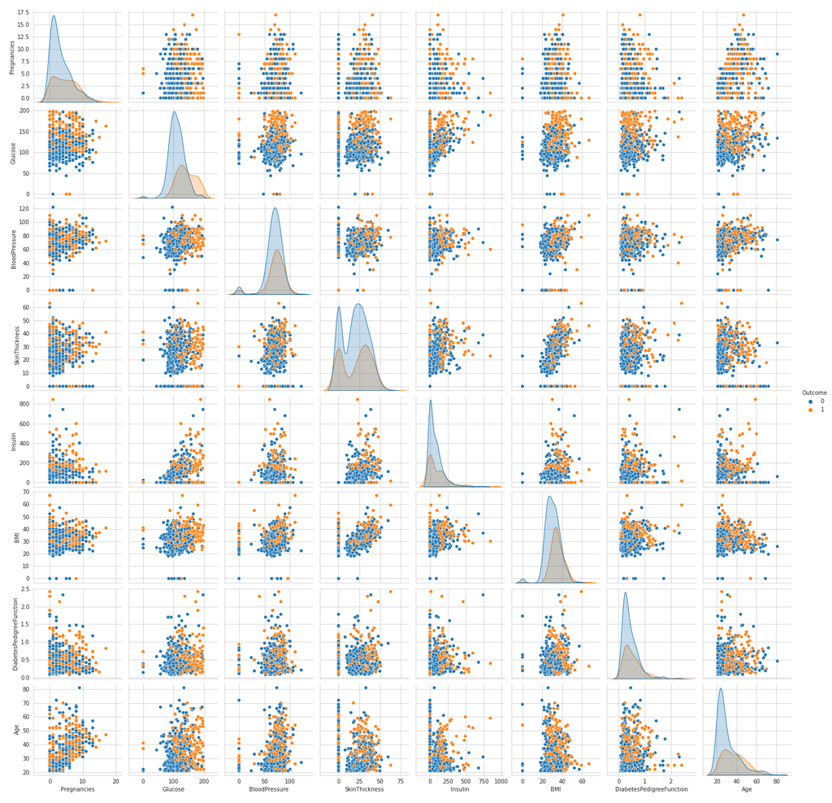

From the analysis of the previous plot, two adequate attributes that seem to separate the classes reasonably well are `Glucose` and `BMI`. Note that for variable `Glucose` the sample distribution for each class are considerably different in terms of mean, median, mode and shape (kurtosis and skew). Regarding variable `BMI`, there is a variation in the mean from class 0 to class 1 without a significant variation in the standard deviation (which is about 6.6 for both classes). If we compute the correlations between the variables and the `Outcome` (class), the highest correlation is for variables `Glucose` and `BMI` as can be seen in the table below. Therefore, this was the chosen two variables to proceed the analysis.

| Variables | Outcome |
| --- | --- |
| Pregnancies | 0.221898 |
| Glucose | 0.466581 |
| BloodPressure | 0.065068 |
| SkinThickness | 0.074752 |
| Insulin | 0.130548 |
| BMI | 0.292695 |
| DiabetesPedigreeFunction | 0.173844 |
| Age | 0.238356 |

The scatter plot between `Glucose` and `BMI` is shown bellow, where values equal to zero were removed for both variables.

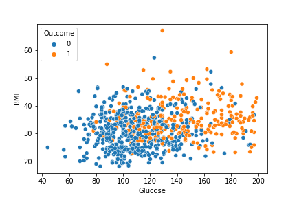

### Q1 - b) Comparison of the behavior of three methods: k-Nearest Neighbors, Logistic Regression and Quadratic Discriminant Analysis

Regarding the comparison of the three classification methods (k-Nearest Neighbors (kNN), Logistic Regression (LogR) and Quadratic Discriminant Analysis (QDA)), we started by dividing the dataset in train set (70%) and test set (30%). Very similar values for the accuracy score were obtained (0.783 for kNN, 0.779 for LogR and 0.779 for QDA - see table bellow). The number of neighbors was chosen based on the graphical analysis shown later in this text, while Logistic Regression and QDA were applied 'off-the-shelf'.

The Bayes Decision Boundary (BDB) may be approximated from sample data with some restrictions. Namely, we assume that the blob of points for each class come from bivariate Gaussian distributions, and that features Glucose and BMI are not correlated. The BDB approximation using sample data statistics is represented in the following figure.

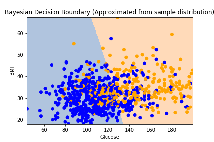

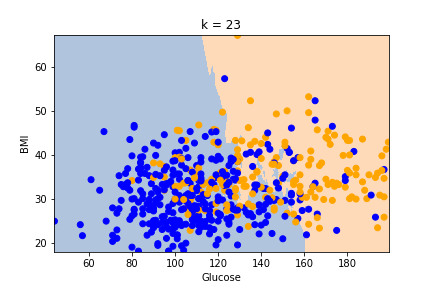

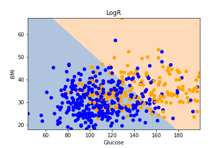

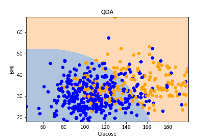

As expected, the more rigid boundary is obtained by Logistic Regression, given the linear boundary assumption. The boundary produced by kNN is more flexible, and it seems to show signs of overfitting in the central region of the plot, where small 'islands' of the blue class and reentrances of the yellow class are formed. The boundary provided by QDA serves as a compromise between the other two. That said, QDA seems to be generating an over complex decision boundary, as the curve shown does not seem to find justification in the plotted sample points.

```python
df_Q1 = io.load_obj('df_Q1_30_kNN23_training')
df_Q1
```

|  | Model | Accuracy train | Accuracy test | Avg. Expected Loss | Avg. Bias | Avg. Var. |
| --- | --- | --- | --- | --- | --- | --- |
| 0 | 23-NN | 0.750951 | 0.783186 | 0.253042 | 0.239544 | 0.081673 |
| 1 | LogR | 0.754753 | 0.778761 | 0.243859 | 0.243346 | 0.023308 |
| 2 | QDA | 0.750951 | 0.778761 | 0.247253 | 0.249049 | 0.024971 |

In the previous table we present the values for models' train and test accuracies obtained through simple hold-out, as well as their average expected loss, average bias and average variance. Estimates for average expected loss, average bias and average variance were obtained by using 200 bootstraped samples from the training dataset.

As stated before, all models (kNN, LogR and QDA) try to approximate the Bayes Decision Boundary in some way. Although the assumptions of the considered models are different, the Average Expected Loss, Average Bias and Average Variance are also very close. That said, it is interesting to notice that kNN presents lower bias error and higher variance error than Logistic Regression and QDA, which is expected since this is the more expressive algorithm. However, this depends on the chosen number of neighbors $k$. The following plot presents the evolution of the Average Expected Loss, Average Bias and Average Variance with $k$. It can be noticed that with the decrease of expressivity (i.e. increase of $k$) the variance component of the error decreases and the Bias component of the error increases.

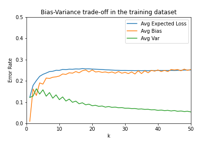

Similarly to the previous discussion, Logistic Regression presents lowest variance error among models, which was also expected since it is the less expressive model of the three. However, we also expected it to exhibit the highest Bias error instead of QDA. This may be explained by the fact that the obtained differences are very low and with a slightly resampling we may obtain a higher bias for logistic regression. Indeed, if we use all the dataset (and not only the training dataset) to compute loss, bias, and variance, logistic regression exhibits the highest bias error, as seen in the table below.

```python
df_Q1_2 = io.load_obj('df_Q1_30_kNN23_all')
df_Q1_2
```

|  | Model | Accuracy train | Accuracy test | Avg. Expected Loss | Avg. Bias | Avg. Var. |
| --- | --- | --- | --- | --- | --- | --- |
| 0 | 23-NN | 0.750951 | 0.783186 | 0.250047 | 0.236702 | 0.080472 |
| 1 | LogR | 0.754753 | 0.778761 | 0.235047 | 0.238032 | 0.021562 |
| 2 | QDA | 0.750951 | 0.778761 | 0.237161 | 0.235372 | 0.022214 |

## Q1 - c) Choose empirically the best value for k. Demonstrate graphically.

### Use plotting to identify situations where overfitting and underfitting occur.

In the following figure is represented the variation of the classification error with $k$ in the train and tests sets.

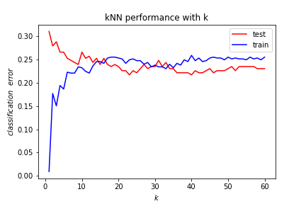

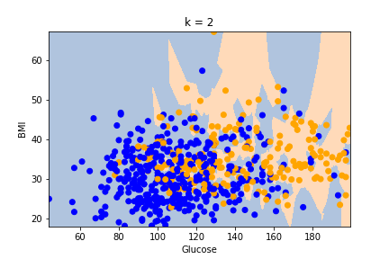

With the increase of $k$, the classification error of the train set increases while the classification error of the test set decreases. The classification error for the test set reaches its minimum value for $k=23$, indicating that for higher values of $k$ the model may be directed to underfit. It should also be referred that test set accuracy also surpasses 0.75 with $k \approx 15$, as can be seen in the first figure of the current section.

## Q1 - Conclusion

The classification algorithms kNN, logistic regression and quadratic discriminant analysis were applied to the training dataset consisting of features BMI and Glucose, where each case is a patient. The objective of the task is correctly classifying the presence or absence of diabetes in a patient. The objective of this work, though, was to explore the characteristics and behavior of the algorithms.

In regards to kNN, the typical overfitting for low k values ($k$=2) is present. Underfitting is not clearly visible, but one might perform the mental exercise - setting a very high number of neighbors, all new cases would be classified as the majority class, thus incurring in severe underfitting. Small differences in test accuracy are spotted for $k$ higher than 15. The best test performance for kNN was obtained for $k=23$. The accuracy scores were very similar among methods, ranging between 0.783 for kNN and 0.779 for Logistic Regression and QDA. Regarding the bias-variance trade-off, the model fit with kNN presents the highest average variance error (by a factor of 4), which is expected since kNN it is the most expressive algorithm among the three. The average bias for the three models fit is very similar, thus pointing either model as presenting the lowest bias is arguable. As noted, kNN's average bias and variance estimates depend on the chosen $k$: with the decrease of expressivity (increase of $k$), the variance component of the error decreases as the bias component of the error increases.

The linear boundary assumed by the model fit with logistic regression is simple, and as it reaches a test accuracy score similar to the models fit with the more expressive kNN and QDA, it might be that the real decision boundary is indeed simpler, i.e. the assumption is correct. We've also seen that both decision boundaries from models fit with logistic regression and kNN somewhat resemble the Bayes Decision Boundary approximated from the sample data. That said, even the best model fit with kNN (23 neighbors) seems to incur in some overfitting in the most central region of the decision boundary analyzed plot analyzed. This is denoted by the 'islands' and reincursions in the boundary between classes. The model fit with QDA, instead, generated a curve decision boundary that might be over complex, as it did not incur in any clear benefit over the remaining models. Finally, the decision boundaries generated by each model are interesting proxies to their behavior, which (in this case) did not influence their performance negatively when compared against each other.

## Question 2: Model selection

In the search for a model that best responds to our problem, first of all it is important to understand all the issues of the problem. The researchers should trace the objectives and requirements of the project, and keep in mind the business problem. In that case, we have a classification problem, that corresponds to predicting the protein location. Nothing more was mentioned about the definition of the problem.

Thus, this study will focus on the exploration of the behavior and characteristics of algorithms in order to select a classification model that has a reasonable performance in this dataset, considering a classification task on imbalanced data (this characteristic of the dataset will be clarified in the next paragraphs).

According to CRISP-DM process model, the next step after defining the business problem is to understand the data.

```python
sns.set_style('whitegrid')
rnd = 0
```

```python
df_yeast = pd.read_csv('../data/yeast.csv')
```

The dataset has 8 numeric attributes and one target variable named Class. The target variable has labels for a total of 10 classes. According to the absolute (count plot below) and relative frequencies (table below) of the cases of each class, it is assumed we are facing an imbalanced classification problem, as the majority class consists of more than 31% of the examples and the minority class represents less than 0.5%.

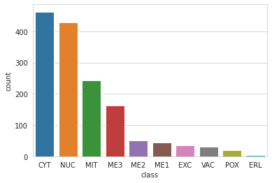

```python
sns.countplot(x='class', data=df_yeast, order = df_yeast['class'].value_counts().index);
```

```python
count = df_yeast['class'].value_counts().to_frame('count')
count['%'] = count['count'] / count['count'].sum()*100
print(count)
```

```
     count          %
CYT    463  31.199461
NUC    429  28.908356
MIT    244  16.442049
ME3    163  10.983827
ME2     51   3.436658
ME1     44   2.964960
EXC     35   2.358491
VAC     30   2.021563
POX     20   1.347709
ERL      5   0.336927
```

Imbalanced classification poses a challenge for predictive modeling as most of the machine learning algorithms used for classification were designed around the assumption of an equal number of examples for each class. Besides, the minority class is harder to predict because there are few examples of this class, i.e. it is more challenging for a model to learn the characteristics of examples from this class, and to differentiate examples from this class from the majority class or classes.

The next phase of CRISP-DM method is data preparation, however our data is clean, it does not need any transformation. Therefore, we can go to the modeling phase which consists of discovering the best function that is able to reasonably estimate the classes for new cases.

## Train-test split / Hold-out

It is desirable to split the dataset into train and test sets in a way that preserves the same proportions of examples in each class as observed in the original dataset, specially in the context where under represented classes are present. We can achieve this by setting the “stratify” argument in the train_test_split() function to ensure that both the train and test sets have the same proportion of examples in each class. The train set consists of 80% of the available data.

```python
X = df_yeast.drop(['Sequence_name','class'], axis=1)
y = df_yeast['class']
# Using stratification on hold out because of imbalance
X_train, X_test, y_train, y_test = train_test_split(X, y, test_size=0.2, stratify=y, random_state=0)
```

## Grid Search with k-fold Cross Validation - GridSearchCV

A grid search procedure with stratified k-fold cross validation strategy was used in order to aid in the selection of hyperparameters for the three models evaluated. In order to avoid the absence of under represented classes in folds, the maximum number of folds is defined as the minimum number of examples of the most under represented class. Searches were carried using two different scoring criteria - accuracy and f1 macro. The selection of hyperparameters with the grid search procedure comes with a cost of interpretability. Therefore, the results are used as benchmarks, or points of reference, to enrich the following discussion on the algorithms and their produced models.

The hyperparameter spaces searched, the selected, and the test set scores for each algorithm are shown in the annex.

## kNN Algorithm

The k nearest neighbors approach assumes that near cases tend to be similar, i.e. pertain to the same classes. It is a reasonable assumption, but when points of different classes are overlapping, misclassification may occur easily. This situation is also more common in minority classes.

We understand that due to this, and the sparsity of points spread in the 8 dimensions relative to the feature space, the GridSearchCV procedure chooses the hyperparameter 'weights' as 'distance' for all experiments, effectively giving more weight to the points with lowest distance. That is, closer neighbors of a query point will have a greater influence than neighbors which are further away.

KNeighborsClassifier is not learned from the data, but it can be tuned, finding the ideal number of neighbors ($k$) that minimizes the loss function. As noted before, the choice of $k$ through grid search does not provide explanations. Therefore, we use repeated kfold cross-validation to robustly estimate the accuracy and f1 macro scores for models fit with different $k$ values for neighbors, and identify the most appropriate value for $k$ graphically. F1 macro is the unweighted mean of the f1 scores for each class.

Finally, each fold must have examples of each class for models fit in each fold to learn from. To ensure the frequency of classes is equivalent to the entire dataset, the cross validation procedure also stratifies cases accordingly.

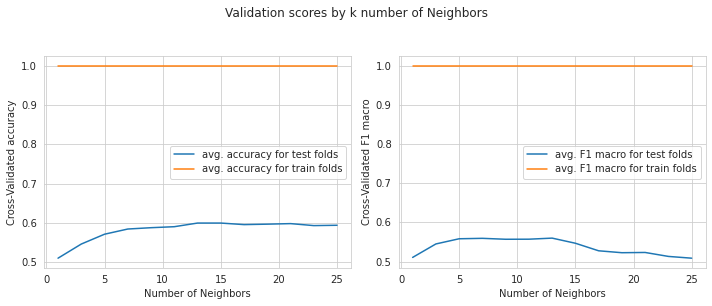

```python
k_range = range(1, 26, 2)
accuracy = []
f1 = []
accuracy_train = []
f1_train = []
cv=RepeatedStratifiedKFold(n_splits=3, n_repeats=3, random_state=1)

for k in k_range:
    # We instantiate the classifier
    knn = KNeighborsClassifier(n_neighbors=k, weights= 'distance', n_jobs=-1)

    scores_acc = cross_val_score(knn, X_train, y_train, cv=cv, scoring='accuracy')
    accuracy.append(scores_acc.mean())

    scores_f1 = cross_val_score(knn, X_train, y_train, cv=cv, scoring='f1_macro')
    f1.append(scores_f1.mean())

    scores_accuracy_train = cross_validate(knn, X_train, y_train, cv=cv,scoring='accuracy',return_train_score=True)
    accuracy_train.append(scores_accuracy_train['train_score'].mean())

    scores_f1_train = cross_validate(knn, X_train, y_train, cv=cv,scoring='f1_macro',return_train_score=True)
    f1_train.append(scores_f1_train['train_score'].mean())

# Visualization of k values vs accuracy
fig, axes = plt.subplots(nrows=1, ncols=2, figsize=(10, 4))
fig.suptitle('Validation scores by k number of Neighbors', y= 1.05)
axes[0].plot(k_range, accuracy, label = "avg. accuracy for test folds")#'Validation Accuracy')
axes[0].plot(k_range, accuracy_train, label = "avg. accuracy for train folds")#''Training Accuracy')
axes[0].set(xlabel='Number of Neighbors', ylabel='Cross-Validated accuracy')
axes[0].legend(loc='center right')

axes[1].plot(k_range, f1, label = "avg. F1 macro for test folds")#'Validation F1 Score')
axes[1].plot(k_range, f1_train, label = "avg. F1 macro for train folds")#'Training F1 Score')
axes[1].set(xlabel='Number of Neighbors', ylabel='Cross-Validated F1 macro')
axes[1].legend()
fig.tight_layout()
```

These graphs show the average accuracy and F1 macro scores for the train and test folds. As chosen by the GridSearchCV procedure, greater importance is given to closer neighbors. We observe that each model, regardless of the number of neighbors, perfectly fits the train folds. However, the performance of the model on validation test set is significantly inferior. The models are not able to generalize well and the models overfit, as seen by low test and high train fold scores. As noted before, this may be due to the sparsity of points in the feature space, along with the weights given to closer points, and the under representation of some classes.  
Considering the lines referent to the test fold shown in the previous plots (in blue), accuracy score stabilizes around $k$ equal to 14 neighbors - the same obtained through Grid Search when accuracy is the scoring criteria. By increasing $k$ beyond this threshold accuracy decays very slowly, while f1 macro decays more steeply. It is known that accuracy ignores imbalance in data sets, being generally higher because it is a score calculated globally, while f1 tries to account for imbalance. This may imply that by choosing more than 14 neighbors, misclassification of under represented classes is even higher, whereas the classification of remaining classes, represented by overall accuracy, is not as affected.

For those reasons, a model with 14 neighbors is selected, which is a model that simultaneously maximizes the accuracy (0.60) and f-score (0.56). Once an appropriate value of $k$ is set, we use the model fit on the test set obtained earlier through hold out, which acts as a future unseen data, to find how the model performs.

```python
kNN = KNeighborsClassifier(n_neighbors=14, weights= 'distance', n_jobs=-1)
kNN.fit(X_train, y_train)
evaluator(X_test, y_test, kNN);
```

```
Test classification report:
              precision    recall  f1-score   support

         CYT       0.57      0.74      0.65        93
         ERL       1.00      1.00      1.00         1
         EXC       0.50      0.43      0.46         7
         ME1       0.67      0.67      0.67         9
         ME2       0.62      0.50      0.56        10
         ME3       0.81      0.69      0.75        32
         MIT       0.63      0.55      0.59        49
         NUC       0.63      0.59      0.61        86
         POX       1.00      0.50      0.67         4
         VAC       0.00      0.00      0.00         6

    accuracy                           0.63       297
   macro avg       0.64      0.57      0.59       297
weighted avg       0.62      0.63      0.62       297


Test confusion matrix:
[[69  0  0  0  0  0  5 19  0  0]
 [ 0  1  0  0  0  0  0  0  0  0]
 [ 1  0  3  0  0  0  3  0  0  0]
 [ 0  0  2  6  1  0  0  0  0  0]
 [ 1  0  0  3  5  0  0  1  0  0]
 [ 5  0  0  0  0 22  2  3  0  0]
 [14  0  0  0  1  1 27  6  0  0]
 [28  0  0  0  1  1  5 51  0  0]
 [ 1  0  0  0  0  0  1  0  2  0]
 [ 1  0  1  0  0  3  0  1  0  0]]

~~~~~~~~~~~~~~~~~~~~~
```

In the test set the accuracy and f1 macro score were sightly better than in the training set, 0.63 and 0.59 respectively.

Analyzing these evaluation measures in more detail, we are not able to state that we have a good model for the purpose of classifying future examples. Only 63% of the estimated classes are correct and the model is not able to predict under represented classes properly.

The kNN algorithm reasons locally regarding loss function minimization. In that sense, training points need to be sufficiently dense. This is not the case for the studied dataset. Six classes out of the ten have less than 5% of the total number of cases each, so the estimate of classes is very hard.

## Logistic Regression

Logistic regression is a linear model for classification, it assumes linear decision boundary. This linear assumption tends to create a very simplistic model that has high bias. Controlling the regularization strength, we can control the complexity of the model. A complex model adapts better to the data, reduces the bias and decreases the potential of underfitting. The following graphs show the average accuracy and f-score calculated with cross validation for different values of the parameter C.

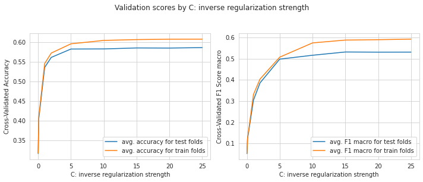

```python
C_range = [0.01, 0.1, 1, 2, 5, 10, 15, 20, 25]
accuracy = []
f1 = []
accuracy_train = []
f1_train = []
cv=RepeatedStratifiedKFold(n_splits=3, n_repeats=3, random_state=1)

for c in C_range:
    # We instantiate the classifier
    LogR = LogisticRegression(C=c, n_jobs=-1, random_state=0, max_iter=1000)

    scores_acc = cross_val_score(LogR, X_train, y_train, cv=cv, scoring='accuracy')
    accuracy.append(scores_acc.mean())

    scores_f1 = cross_val_score(LogR, X_train, y_train, cv=cv, scoring='f1_macro')
    f1.append(scores_f1.mean())

    scores_accuracy_train = cross_validate(LogR, X_train, y_train, cv=cv,scoring='accuracy',return_train_score=True)
    accuracy_train.append(scores_accuracy_train['train_score'].mean())

    scores_f1_train = cross_validate(LogR, X_train, y_train, cv=cv,scoring='f1_macro',return_train_score=True)
    f1_train.append(scores_f1_train['train_score'].mean())

# Visualization of C values vs accuracy
fig, axes = plt.subplots(nrows=1, ncols=2, figsize=(10, 4))
fig.suptitle('Validation scores by C: inverse regularization strength', y= 1.05)
axes[0].plot(C_range, accuracy, label = "avg. accuracy for test folds")#Set")
axes[0].plot(C_range, accuracy_train, label = "avg. accuracy for train folds")#Set")
axes[0].set(xlabel='C: inverse regularization strength', ylabel='Cross-Validated Accuracy')
axes[0].legend()
axes[1].plot(C_range, f1, label = "avg. F1 macro for test folds")#Set")
axes[1].plot(C_range, f1_train, label = "avg. F1 macro for train folds")#Set")
axes[1].set(xlabel='C: inverse regularization strength', ylabel='Cross-Validated F1 Score macro')
axes[1].legend()
fig.tight_layout()
```

```python
LogR = LogisticRegression(C=15, n_jobs=-1, random_state=0, max_iter=1000)
LogR.fit(X_train, y_train)
evaluator(X_test, y_test, LogR);
```

```
Test classification report:
              precision    recall  f1-score   support

         CYT       0.51      0.74      0.61        93
         ERL       1.00      1.00      1.00         1
         EXC       0.50      0.29      0.36         7
         ME1       0.75      0.67      0.71         9
         ME2       0.50      0.50      0.50        10
         ME3       0.79      0.72      0.75        32
         MIT       0.62      0.53      0.57        49
         NUC       0.59      0.45      0.51        86
         POX       1.00      0.50      0.67         4
         VAC       0.00      0.00      0.00         6

    accuracy                           0.58       297
   macro avg       0.63      0.54      0.57       297
weighted avg       0.59      0.58      0.57       297


Test confusion matrix:
[[69  0  0  0  0  0  6 18  0  0]
 [ 0  1  0  0  0  0  0  0  0  0]
 [ 1  0  2  0  1  0  3  0  0  0]
 [ 0  0  1  6  2  0  0  0  0  0]
 [ 1  0  0  2  5  0  1  1  0  0]
 [ 7  0  0  0  0 23  0  2  0  0]
 [16  0  0  0  1  1 26  5  0  0]
 [39  0  0  0  1  2  5 39  0  0]
 [ 1  0  0  0  0  0  1  0  2  0]
 [ 1  0  1  0  0  3  0  1  0  0]]

~~~~~~~~~~~~~~~~~~~~~
```

It is possible to observe in the outcome above that accuracy and f-score are equal to 58.25% and 56.8%, respectively. The classification performance against the test set is similar to what was obtained against the validation set. It is also similar to the performance of the model fit by logistic regression found by the grid search procedure.

Is the logistic regression fit model a good solution for our classification problem?

According to test set, this model only estimates correctly 58.25% of the classes, while the f1-score obtained is also ordinary (0.568). As with kNN, none of the six examples of class VAC was correctly predicted and the results from the more expressive algorithms were similar, so the bottleneck is more likely to be the imbalance in data than the bias component of the error associated with the strong assumptions of logistic regression.

## Decision Tree

Decision tree training is a recursive process that continually partitions data until a end condition is met. A tree is built by splitting the source set, constituting the root node of the tree, into subsets. The split points of the tree are chosen to best separate examples into two groups with minimum mixing and according to the information gain criteria result, using a quality measure. There are two methods for evaluating the split quality, and both are commonly used. The Grid Search CV obtains the best results using entropy as criteria for both scoring criteria (accuracy and f1 macro), thus, the same selection is made for this experiment.

When both groups are dominated by examples from one class, the criterion used to select a split point will see good separation, when in fact, the examples from the minority class are being ignored. The splitting criterion can be updated to not only to take the purity of the split into account, but also be weighted by the inverse of the frequency of each class. A small weight can be assigned to the majority class, which has the effect of improving the purity score of a node that may otherwise ignore the minority classes. Even with the class weight adjustment, a decision tree will overfit the data if we keep splitting indefinitely.

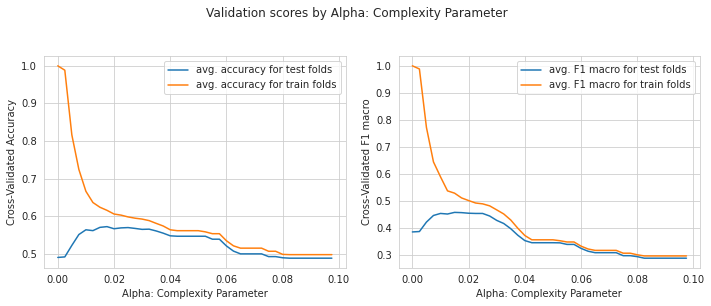

```python
ccp_alpha_range = np.arange(0.0, 0.1, 0.0025)
accuracy = []
f1 = []
accuracy_train = []
f1_train = []
cv=RepeatedStratifiedKFold(n_splits=3, n_repeats=3, random_state=1)

for alpha in ccp_alpha_range:
    # We instantiate the classifier
    DTree = DecisionTreeClassifier(criterion='entropy', ccp_alpha = alpha, random_state=0)

    scores_acc = cross_val_score(DTree, X_train, y_train, cv=cv, scoring='accuracy')
    accuracy.append(scores_acc.mean())

    scores_f1 = cross_val_score(DTree, X_train, y_train, cv=cv, scoring='f1_macro')
    f1.append(scores_f1.mean())

    scores_accuracy_train = cross_validate(DTree, X_train, y_train, cv=cv,scoring='accuracy',return_train_score=True)
    accuracy_train.append(scores_accuracy_train['train_score'].mean())

    scores_f1_train = cross_validate(DTree, X_train, y_train, cv=cv,scoring='f1_macro',return_train_score=True)
    f1_train.append(scores_f1_train['train_score'].mean())

# Visualization of C values vs accuracy
fig, axes = plt.subplots(nrows=1, ncols=2, figsize=(10, 4))
fig.suptitle('Validation scores by Alpha: Complexity Parameter', y= 1.05)
axes[0].plot(ccp_alpha_range, accuracy, label = "avg. accuracy for test folds")#Set")
axes[0].plot(ccp_alpha_range, accuracy_train, label = "avg. accuracy for train folds")#Set")
axes[0].set(xlabel='Alpha: Complexity Parameter', ylabel='Cross-Validated Accuracy')
axes[0].legend()
axes[1].plot(ccp_alpha_range, f1, label = "avg. F1 macro for test folds")#Set")
axes[1].plot(ccp_alpha_range, f1_train, label = "avg. F1 macro for train folds")#Set")
axes[1].set(xlabel='Alpha: Complexity Parameter', ylabel='Cross-Validated F1 macro')
axes[1].legend()
fig.tight_layout()
```

The plots above are generated using repeated stratified cross-validation with three folds and three repetitions over the decision tree algorithm using entropy as splitting criteria and without weighting classes. The training accuracy is 100% when pruning is not done, and the classification errors are very high on test folds. If the model is not able to generalize, small changes in the data will greatly affect prediction. Pruning reduces the size of a Decision Tree which might increase the training error but decrease the testing error, hence making it more generalizable. There are two ways to control tree size, stop splitting the tree at some point, that is known to prepruning, or generating a complete tree first, and then get rid of some branches, which is called post pruning. We chose post pruning by varying the value of cost complexity pruning (ccp_alpha), which is a more broader approach than its counterparts. As the tree is pruned, accuracy and f-score abruptly decrease on the train folds, reducing overfit. As cost complexity increases, more of the tree is pruned, which increases the total impurity of its leaves. On the other hand, when the tree is too small, that is, when ccp_alpha is high, the model clearly underfits. Visually, the hyperparameter ccp_alpha equal to 0.015 seems to maximize both accuracy and f1 macro. That said, the hyperparameters chosen by the grid search procedure using accuracy as scoring is equal to 0.0075. This reflects the difficulty in selecting a proper pruning value. Setting ccp_alpha as 0.015, the evaluation of the model fit against test data is shown below.

```python
DTree = DecisionTreeClassifier(criterion='entropy', ccp_alpha = 0.015, random_state=0)
DTree.fit(X_train, y_train)
evaluator(X_test, y_test, DTree);
```

```
Test classification report:
              precision    recall  f1-score   support

         CYT       0.51      0.75      0.61        93
         ERL       0.00      0.00      0.00         1
         EXC       0.33      0.29      0.31         7
         ME1       0.50      0.56      0.53         9
         ME2       0.38      0.50      0.43        10
         ME3       0.72      0.88      0.79        32
         MIT       0.61      0.45      0.52        49
         NUC       0.59      0.37      0.46        86
         POX       1.00      0.25      0.40         4
         VAC       0.00      0.00      0.00         6

    accuracy                           0.56       297
   macro avg       0.46      0.40      0.40       297
weighted avg       0.56      0.56      0.54       297


Test confusion matrix:
[[70  0  1  0  2  2  5 13  0  0]
 [ 0  0  0  0  1  0  0  0  0  0]
 [ 1  0  2  1  0  0  3  0  0  0]
 [ 0  0  2  5  2  0  0  0  0  0]
 [ 2  0  0  3  5  0  0  0  0  0]
 [ 4  0  0  0  0 28  0  0  0  0]
 [15  0  0  0  1  2 22  9  0  0]
 [44  0  1  0  1  3  5 32  0  0]
 [ 1  0  0  0  0  1  1  0  1  0]
 [ 1  0  0  1  1  3  0  0  0  0]]

~~~~~~~~~~~~~~~~~~~~~
```

The model returned a accuracy value of 0.56 and f1 macro of 0.4. This performance is similar to the observed in the models obtained from other algorithms evaluated. Although we tried to overcome the specificities of this database and avoided the overfit of the model, the scores obtained were not satisfactory.

## Conclusion

After analyzing the three methods, we cannot state that the performance of any model was much better than their counterparts. The performances of either kNN, decision trees, or logistic regression were very similar. That said kNN returned marginally better scores - accuracy equal to 0.63, and f1 macro scores equal to 0.59. Moreover, none of the models was able to consistently and correctly predict under represented classes. This is due to the machine learning algorithms being designed under the assumption that the classes are equally represented, and this was the biggest challenge of the classification task. In this dataset, the ratio between the most common class and the least common is 100:1, which severely dampens all three algorithms.

Considering the kNN approach, if we choose a small number of neighbors, the model does not generalize and overfits, but if we increase the number of neighbors the majority vote used by the algorithm will necessarily account for cases of wrong classes. The algorithm tried to minimize this issue by giving more importance to neighbors that were closer to the case being classified. That said, poor performance is expected as kNN requires training data to be sufficiently dense to be able to generalize predictions.

In contrast, the kNN and Decision Tree approaches are more flexible algorithms, as they do not have strong assumptions about data. They can be applied to data with linear and non-linear relationships among the features, although they can easily overfit. A dataset contains a mix of signal and noise. An algorithm is expected to learn the signal. However, when the complexity of an algorithm increases, it also starts to include noise in the model through the learning process. Therefore, it produces exceedingly good results for the dataset it trained on but fails to generalize, performing poorly on other previously unseen data. In other words, the bias of the algorithm is very low while its variance is very high. This instability can be minimized by reducing its expressiveness, allowing an increase of bias error. We have to be careful when increasing bias at the risk of turning the model ineffective. We can conclude that an ideal algorithm would be one where both the bias error and the variance error are low. In this project we have attempted to use these algorithms to their fullest potential. To achieve this, we carried out experiments with several relevant hyperparameters relative to each algorithm. The results were mediocre because none of the methods could overcome the severe unbalancing of the dataset, failing to generalize and give good predictions for every class. Specifically, the performance of the classification task for underrepresented classes (such as `ERL`, `POX` and `VAC`) is variable and generally poor. This is not surprising given the previous discussion. Perhaps using methods such as oversampling and/or undersampling could improve the obtained results.

## References

[1] [Feature Selection Techniques in Machine Learning with Python](https://towardsdatascience.com/feature-selection-techniques-in-machine-learning-with-python-f24e7da3f36e)

[2] [Bias variance decomposition of a decision tree classifier](https://rasbt.github.io/mlxtend/user_guide/evaluate/bias_variance_decomp/#example-1-bias-variance-decomposition-of-a-decision-tree-classifier)

[3] Domingos, Pedro. "A unified bias-variance decomposition." Proceedings of 17th International Conference on Machine Learning. 2000.

## Appendix

### On the results of the Grid Search procedure

The hyperparameter spaces searched for each algorithm are:

- kNN:
  - neighbors: 1 - 50
  - weights (are weights uniform or decrease with distance): uniform, distance
  - p (power of the Minkowski metric. 1 - Manhattan, 2 - Euclidean): 1 - 2
- Logistic Regression:
  - C (inverse regularization strength): 0.5 - 20.0, step of 0.5
  - fit intercept (should bias be added): True, False
  - class weight (should weights be given according to the inverse of class frequency): None, balanced
- Decision Trees:
  - criterion (measure of quality of a split): gini, entropy
  - class weight (should weights be given according to the inverse of class frequency): None, balanced
  - ccp_alpha (Complexity parameter used for Minimal Cost-Complexity Pruning): 0.0 - 10.0, step of 0.0025

The hyperparameters chosen for each algorithm using different scoring criteria are:

| kNN / cv scoring | accuracy | f1 macro |
| --- | --- | --- |
| neighbors | 14 | 7 |
| weights | distance | distance |
| p | 1 | 2 |

| Logistic Regression / cv scoring | accuracy | f1 macro |
| --- | --- | --- |
| C | 8.5 | 10 |
| fit intercept | True | True |
| class weight | None | None |

| Decision Tree / cv scoring | accuracy | f1 macro |
| --- | --- | --- |
| criterion | entropy | entropy |
| class weight | None | balanced |
| ccp alpha | 0.0075 | 0.055 |

The test scores of models fit with the chosen hyperparameters are shown below.

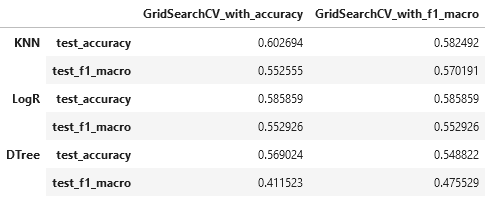